# 2023农业系统模型与大数据分析实验课作业2

```python
### 姓名： 郑元浩
### 学号：22213014
```

# 1. 数据预处理

目的：

1. 了解并熟悉数据预处理和汇总分析流程: （1）数据读取 （2）异常值处理 （3）对原始值分布进行可视化和汇总分析（总览，年际变化等） （4）气象指标计算 （5）基于气象指标的汇总分析（总览，年际变化等） （6）生成样本集并导出

Case: 对美国Iowa州2001-2016年玉米单产与气象数据筛选清洗，计算气象指标，生成一份样本集，总结Iowa州历史气象条件及其年际变化情况。

通过绘图和统计分析回答文档中的4个问题，并请将该份文件保存并导出成html并邮箱发送至renhaizhong@zju.edu.cn

（左上角：File → Download as → HTML(.html)）

文件命名格式：2023农业系统模型与大数据分析实验课作业2_姓名_学号

1.产量波动是否与气象条件的波动有关？ 产量波动与气象条件的波动有关系。气象条件降水pcpn大致趋势2008年之前逐渐升高、2008-2012趋势降低、2012之后又回升，高温胁迫累计基本趋势与之相反，产量大致趋势则2008年之前逐渐升高、2008-2012趋势降低、2012之后又回升，可见产量波动与气象条件的波动有关系。

2.2012年的减产原因是什么？2012年各气象条件与历史平均水平差异多大？ 2012年减产的气象原因为降雨量明显降低，高温胁迫累计明显增高，气象异常，出现了较为反常的高温干旱天气，导致减产。

3.各气象条件和指标在玉米生长期（5-9月）不同月份间是否存在差异？ 不同月份之间温度指标存在差异，而降雨量基本差别不大。由GDD、KDD、pcpn月度统计图可以看出，月度积温GDD与高温胁迫KDD5-7月逐月上升、7-9月逐月下降，降雨量基本持平或略呈下降趋势，与北半球夏季特征基本吻合。

4.玉米生长期各气象指标年际变化如何？ 各气象指标不同年份之间存在差异，但是受气象条件影响，并无明显规律性。

```python
#引入模块
import random
import pandas as pd
import matplotlib.pyplot as plt
%matplotlib inline
```

```python
#读取数据
df_yield =  pd.read_csv('corn_yield_IA_2001_2016.csv',header=0,index_col=None)#单产数据
df_clim =   pd.read_csv('daily_clim_IA_2001_2016.csv',header=0,index_col=None)#气象数据
```

## 产量数据部分

```python
# 查看数据前5行
df_yield.head(5)
```

|  | fips | county | state | Year | Ton_ha | state_fips |
| --- | --- | --- | --- | --- | --- | --- |
| 0 | 19197 | iowa,wright | Iowa | 2011 | 11.920021 | 19 |
| 1 | 19193 | iowa,woodbury | Iowa | 2013 | 10.306832 | 19 |
| 2 | 19141 | iowa,o'brien | Iowa | 2004 | 11.442969 | 19 |
| 3 | 19173 | iowa,taylor | Iowa | 2004 | 9.911381 | 19 |
| 4 | 19097 | iowa,jackson | Iowa | 2001 | 9.541038 | 19 |

```python
# 数据概览
df_yield.describe()
```

|  | fips | Year | Ton_ha | state_fips |
| --- | --- | --- | --- | --- |
| count | 1580.000000 | 1580.000000 | 1580.000000 | 1580.0 |
| mean | 19098.863291 | 2008.483544 | 10.412993 | 19.0 |
| std | 57.170581 | 4.605430 | 1.562791 | 0.0 |
| min | 19001.000000 | 2001.000000 | 2.793265 | 19.0 |
| 25% | 19049.000000 | 2004.000000 | 9.608516 | 19.0 |
| 50% | 19099.000000 | 2008.000000 | 10.648929 | 19.0 |
| 75% | 19149.000000 | 2012.000000 | 11.471216 | 19.0 |
| max | 19197.000000 | 2016.000000 | 13.790567 | 19.0 |

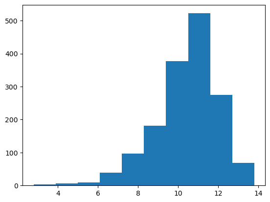

```python
# 查看历史单产分布情况
plt.hist( df_yield['Ton_ha'] )
```

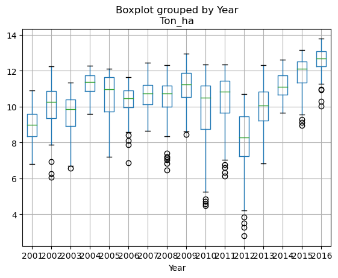

```python
# 查看单产的逐年分布
df_yield.boxplot('Ton_ha',by='Year')
```

问题： 1.产量波动是否与气象条件的波动有关？ 产量波动与气象条件的波动有关系。气象条件降水pcpn大致趋势2008年之前逐渐升高、2008-2012趋势降低、2012之后又回升，高温胁迫累计基本趋势与之相反，产量大致趋势则2008年之前逐渐升高、2008-2012趋势降低、2012之后又回升，可见产量波动与气象条件的波动有关系。

2.2012年的减产原因是什么？2012年各气象条件与历史平均水平差异多大？ 2012年减产的气象原因为降雨量明显降低，高温胁迫累计明显增高，气象异常，出现了较为反常的高温干旱天气，导致减产。

3.各气象条件和指标在玉米生长期（5-9月）不同月份间是否存在差异？ 不同月份之间温度指标存在差异，而降雨量基本差别不大。由GDD、KDD、pcpn月度统计图可以看出，月度积温GDD与高温胁迫KDD5-7月逐月上升、7-9月逐月下降，降雨量基本持平或略呈下降趋势，与北半球夏季特征基本吻合。

4.玉米生长期各气象指标年际变化如何？ 各气象指标不同年份之间存在差异，但是受气象条件影响，并无明显规律性。

## 气象数据部分

```python
# 查看气象数据前5行
df_clim.head(5)
```

|  | date | fips | maxt | mint | avgt | pcpn | isoWeek | Year |
| --- | --- | --- | --- | --- | --- | --- | --- | --- |
| 0 | 2001-01-01 | 19163 | -9.827178 | -18.035846 | -13.943254 | 1.584545 | 1 | 2001 |
| 1 | 2001-01-01 | 19045 | -9.683426 | -15.941118 | -12.794801 | 4.320551 | 1 | 2001 |
| 2 | 2001-01-01 | 19115 | -10.088908 | -21.042717 | -15.567969 | 0.264676 | 1 | 2001 |
| 3 | 2001-01-01 | 19057 | -8.448372 | -19.710912 | -14.081778 | 0.100905 | 1 | 2001 |
| 4 | 2001-01-01 | 19105 | -7.804181 | -14.814290 | -11.278712 | 2.583775 | 1 | 2001 |

```python
# 提取月份作为一列，用于后续的筛选与聚合
df_clim['new_date'] = pd.to_datetime( df_clim['date'] )
df_clim['month'] = df_clim['new_date'].dt.month
df_clim = df_clim.drop( 'new_date', axis = 1 )
df_clim.head(5)
```

|  | date | fips | maxt | mint | avgt | pcpn | isoWeek | Year | month |
| --- | --- | --- | --- | --- | --- | --- | --- | --- | --- |
| 0 | 2001-01-01 | 19163 | -9.827178 | -18.035846 | -13.943254 | 1.584545 | 1 | 2001 | 1 |
| 1 | 2001-01-01 | 19045 | -9.683426 | -15.941118 | -12.794801 | 4.320551 | 1 | 2001 | 1 |
| 2 | 2001-01-01 | 19115 | -10.088908 | -21.042717 | -15.567969 | 0.264676 | 1 | 2001 | 1 |
| 3 | 2001-01-01 | 19057 | -8.448372 | -19.710912 | -14.081778 | 0.100905 | 1 | 2001 | 1 |
| 4 | 2001-01-01 | 19105 | -7.804181 | -14.814290 | -11.278712 | 2.583775 | 1 | 2001 | 1 |

```python
# 筛选月份，美国玉米5月播种，9月成熟
df_clim = df_clim[ df_clim['month'].isin([5,6,7,8,9]) ]
df_clim
```

|  | date | fips | maxt | mint | avgt | pcpn | isoWeek | Year | month |
| --- | --- | --- | --- | --- | --- | --- | --- | --- | --- |
| 960 | 2001-05-01 | 19163 | 28.347706 | 16.064654 | 22.220578 | 0.929856 | 18 | 2001 | 5 |
| 961 | 2001-05-01 | 19045 | 27.953419 | 15.267885 | 21.616542 | 2.035143 | 18 | 2001 | 5 |
| 962 | 2001-05-01 | 19115 | 27.081608 | 16.203484 | 21.615291 | 1.104023 | 18 | 2001 | 5 |
| 963 | 2001-05-01 | 19057 | 27.733150 | 16.363140 | 22.069677 | 0.117419 | 18 | 2001 | 5 |
| 964 | 2001-05-01 | 19105 | 27.278154 | 15.339593 | 21.338141 | 5.180165 | 18 | 2001 | 5 |
| ... | ... | ... | ... | ... | ... | ... | ... | ... | ... |
| 570179 | 2016-09-30 | 19009 | 20.499077 | 5.793525 | 13.167282 | 0.000000 | 39 | 2016 | 9 |
| 570180 | 2016-09-30 | 19003 | 20.810636 | 7.541972 | 14.196582 | 0.000000 | 39 | 2016 | 9 |
| 570181 | 2016-09-30 | 19001 | 21.133465 | 7.494517 | 14.337864 | 0.000000 | 39 | 2016 | 9 |
| 570182 | 2016-09-30 | 19007 | 23.122932 | 8.711408 | 15.962397 | 0.000000 | 39 | 2016 | 9 |
| 570183 | 2016-09-30 | 19005 | 21.624078 | 9.041752 | 15.359289 | 0.067237 | 39 | 2016 | 9 |

242352 rows × 9 columns

```python
# 气象数据概览
df_clim.describe()
```

|  | fips | maxt | mint | avgt | pcpn | isoWeek | Year | month |
| --- | --- | --- | --- | --- | --- | --- | --- | --- |
| count | 242352.000000 | 242352.000000 | 242352.000000 | 242352.000000 | 242352.000000 | 242352.000000 | 242352.000000 | 242352.000000 |
| mean | 19099.000000 | 26.022784 | 13.647509 | 19.861958 | 3.684751 | 28.642565 | 2008.500000 | 6.993464 |
| std | 57.154879 | 5.151049 | 5.039129 | 4.845476 | 8.991797 | 6.322897 | 4.609782 | 1.411889 |
| min | 19001.000000 | -0.137333 | -6.866145 | -0.895596 | 0.000000 | 17.000000 | 2001.000000 | 5.000000 |
| 25% | 19049.000000 | 23.131589 | 10.471081 | 16.943870 | 0.000000 | 23.000000 | 2004.750000 | 6.000000 |
| 50% | 19099.000000 | 26.790884 | 14.193979 | 20.495368 | 0.026451 | 29.000000 | 2008.500000 | 7.000000 |
| 75% | 19149.000000 | 29.552044 | 17.419608 | 23.315627 | 2.563937 | 34.000000 | 2012.250000 | 8.000000 |
| max | 19197.000000 | 41.315825 | 26.328532 | 33.297356 | 174.672877 | 40.000000 | 2016.000000 | 9.000000 |

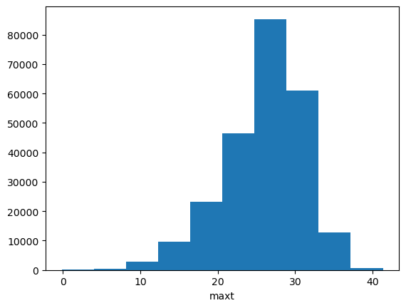

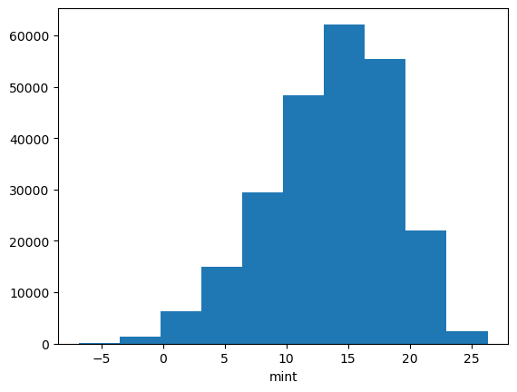

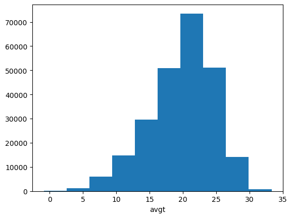

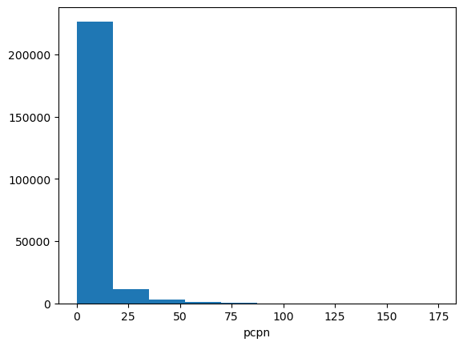

```python
# 查看各气象原始值的分布，例如绘制直方图
t = 0
for i in ['maxt', 'mint', 'avgt', 'pcpn']:
    t+=1
    plt.figure(t)
    plt.hist(df_clim[i])
    plt.xlabel(i)
```

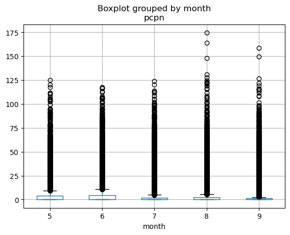

```python
# 查看各月降雨量分布
df_clim.boxplot('pcpn', by='month')
```

```python
# 计算日值气象指标 （GDD, KDD）
df_clim['Tmax'] = df_clim['maxt']
for i,T in df_clim['Tmax'].iteritems():
    if T>=29:
        df_clim['Tmax'][i] = 29
    elif T<=10:
        df_clim['Tmax'][i] = 10

df_clim['Tmin'] = df_clim['mint']
for i,T in df_clim['Tmin'].iteritems():
    if T>=29:
        df_clim['Tmin'][i] = 29
    elif T<=10:
        df_clim['Tmin'][i] = 10

df_clim['GDD'] = (df_clim['Tmax']+df_clim['Tmin'])/2 - 10

df_clim['KDD'] = df_clim['maxt']-29
for i, kdd in df_clim['KDD'].iteritems():
    if kdd<0:
        df_clim['KDD'][i] = 0

df_clim
```

|  | date | fips | maxt | mint | avgt | pcpn | isoWeek | Year | month | Tmax | Tmin | GDD | KDD |
| --- | --- | --- | --- | --- | --- | --- | --- | --- | --- | --- | --- | --- | --- |
| 960 | 2001-05-01 | 19163 | 28.347706 | 16.064654 | 22.220578 | 0.929856 | 18 | 2001 | 5 | 28.347706 | 16.064654 | 12.206180 | 0.0 |
| 961 | 2001-05-01 | 19045 | 27.953419 | 15.267885 | 21.616542 | 2.035143 | 18 | 2001 | 5 | 27.953419 | 15.267885 | 11.610652 | 0.0 |
| 962 | 2001-05-01 | 19115 | 27.081608 | 16.203484 | 21.615291 | 1.104023 | 18 | 2001 | 5 | 27.081608 | 16.203484 | 11.642546 | 0.0 |
| 963 | 2001-05-01 | 19057 | 27.733150 | 16.363140 | 22.069677 | 0.117419 | 18 | 2001 | 5 | 27.733150 | 16.363140 | 12.048145 | 0.0 |
| 964 | 2001-05-01 | 19105 | 27.278154 | 15.339593 | 21.338141 | 5.180165 | 18 | 2001 | 5 | 27.278154 | 15.339593 | 11.308873 | 0.0 |
| ... | ... | ... | ... | ... | ... | ... | ... | ... | ... | ... | ... | ... | ... |
| 570179 | 2016-09-30 | 19009 | 20.499077 | 5.793525 | 13.167282 | 0.000000 | 39 | 2016 | 9 | 20.499077 | 10.000000 | 5.249538 | 0.0 |
| 570180 | 2016-09-30 | 19003 | 20.810636 | 7.541972 | 14.196582 | 0.000000 | 39 | 2016 | 9 | 20.810636 | 10.000000 | 5.405318 | 0.0 |
| 570181 | 2016-09-30 | 19001 | 21.133465 | 7.494517 | 14.337864 | 0.000000 | 39 | 2016 | 9 | 21.133465 | 10.000000 | 5.566733 | 0.0 |
| 570182 | 2016-09-30 | 19007 | 23.122932 | 8.711408 | 15.962397 | 0.000000 | 39 | 2016 | 9 | 23.122932 | 10.000000 | 6.561466 | 0.0 |
| 570183 | 2016-09-30 | 19005 | 21.624078 | 9.041752 | 15.359289 | 0.067237 | 39 | 2016 | 9 | 21.624078 | 10.000000 | 5.812039 | 0.0 |

242352 rows × 13 columns

|  | Tmax | Tmin | GDD | KDD |
| --- | --- | --- | --- | --- |
| count | 242352.000000 | 242352.000000 | 242352.000000 | 242352.000000 |
| mean | 25.314140 | 14.463218 | 9.888679 | 0.720558 |
| std | 4.298609 | 3.751603 | 3.685180 | 1.520738 |
| min | 10.000000 | 10.000000 | 0.000000 | 0.000000 |
| 25% | 23.131589 | 10.471081 | 7.227978 | 0.000000 |
| 50% | 26.790884 | 14.193979 | 10.429607 | 0.000000 |
| 75% | 29.000000 | 17.419608 | 12.877210 | 0.552044 |
| max | 29.000000 | 26.328532 | 17.664266 | 12.315825 |

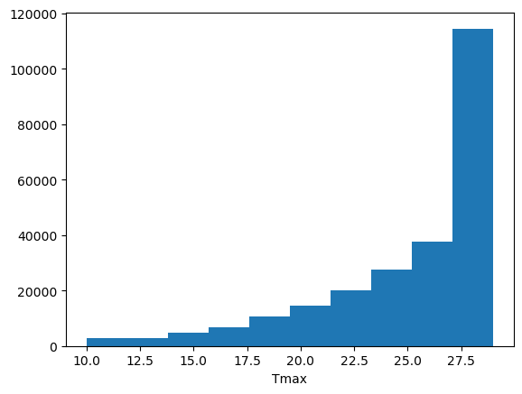

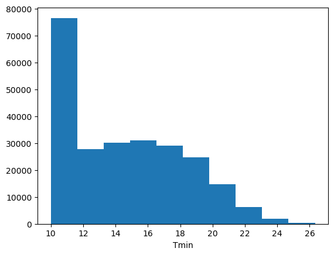

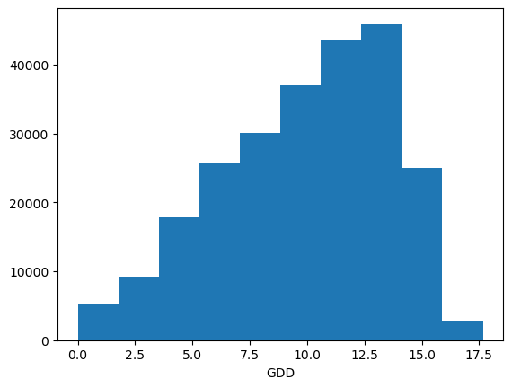

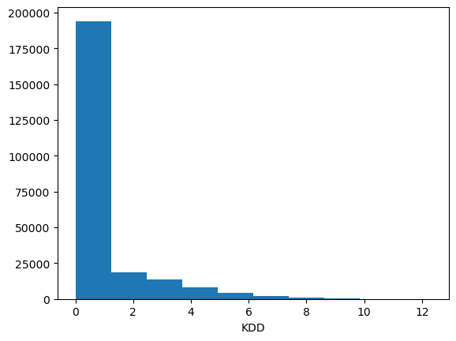

```python
# 查看气象指标的数据概览
t = 0
for i in ['Tmax','Tmin','GDD', 'KDD']:
    t+=1
    plt.figure(t)
    plt.hist(df_clim[i])
    plt.xlabel(i)

df_clim[['Tmax','Tmin','GDD', 'KDD']].describe()
```

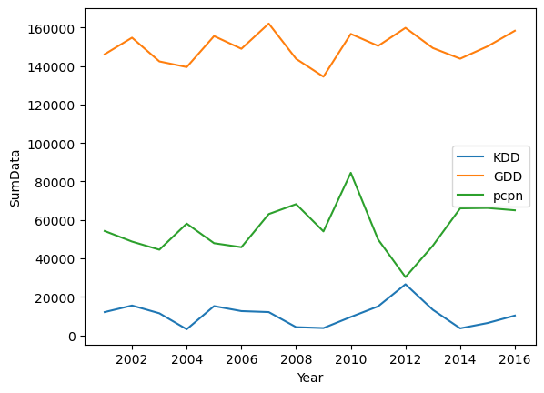

```python
# 计算年累积值以查看年际差异
plt.plot( df_clim.groupby(df_clim['Year'])[['KDD', 'GDD','pcpn']].sum() )
plt.legend( ['KDD', 'GDD','pcpn'] )
plt.xlabel( 'Year' )
plt.ylabel( 'SumData' )
```

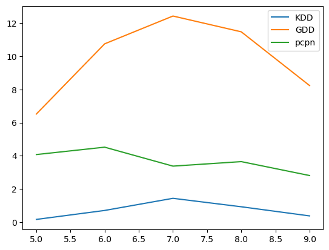

```python
plt.plot( df_clim.groupby(df_clim['month'])[['KDD', 'GDD','pcpn']].mean() )
plt.legend( ['KDD', 'GDD','pcpn'] )
```

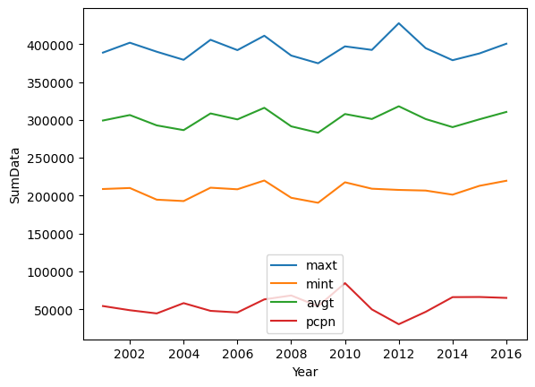

```python
# 查看气象数据在每年的分布情况
plt.plot( df_clim.groupby(df_clim['Year'])[['maxt', 'mint','avgt','pcpn']].sum() )
plt.legend(['maxt', 'mint','avgt','pcpn'] )
plt.xlabel( 'Year' )
plt.ylabel( 'SumData' )
```

```python
# 将日值聚合成月值: 根据fips，Year和Mon，对KDD,GDD,pcpn进行分组求和，即每个FIPS在每一年在每个月份每个气象指标有一个sum值
MergeData = df_clim.groupby(["fips","Year","month"])[['pcpn','KDD','GDD']].sum()
MergeData
```

| fips | Year | month | pcpn | KDD | GDD |
| --- | --- | --- | --- | --- | --- |
| 19001 | 2001 | 5 | 183.614572 | 4.566077 | 199.886975 |
|  |  | 6 | 84.161057 | 20.826575 | 292.135549 |
|  |  | 7 | 54.070042 | 65.134418 | 420.258905 |
|  |  | 8 | 36.839386 | 66.132786 | 376.596771 |
|  |  | 9 | 133.106858 | 11.140578 | 221.937307 |
| ... | ... | ... | ... | ... | ... |
| 19197 | 2016 | 5 | 152.021018 | 1.243863 | 193.117920 |
|  |  | 6 | 114.460675 | 35.098286 | 337.810543 |
|  |  | 7 | 159.962626 | 17.885821 | 366.900239 |
|  |  | 8 | 160.180640 | 11.794824 | 352.561423 |
|  |  | 9 | 246.053759 | 10.038708 | 269.655907 |

7920 rows × 3 columns

```python
# 行列的融合拆分操作1
split_rows = MergeData.reset_index()
FYM = MergeData.pivot_table(index=["fips", "Year"], columns="month", values=["KDD", "GDD", "pcpn"])
FYM
```

| fips | month Year | GDD 5 | GDD 6 | GDD 7 | GDD 8 | GDD 9 | KDD 5 | KDD 6 | KDD 7 | KDD 8 | KDD 9 | pcpn 5 | pcpn 6 | pcpn 7 | pcpn 8 | pcpn 9 |
| --- | --- | --- | --- | --- | --- | --- | --- | --- | --- | --- | --- | --- | --- | --- | --- | --- |
| 19001 | 2001 | 199.886975 | 292.135549 | 420.258905 | 376.596771 | 221.937307 | 4.566077 | 20.826575 | 65.134418 | 66.132786 | 11.140578 | 183.614572 | 84.161057 | 54.070042 | 36.839386 | 133.106858 |
|  | 2002 | 187.804116 | 366.583405 | 423.345459 | 361.012640 | 271.402773 | 4.310433 | 37.955917 | 86.189579 | 26.885847 | 30.431396 | 106.772225 | 47.615061 | 85.118728 | 112.219295 | 49.861284 |
|  | 2003 | 172.053358 | 282.070340 | 389.177585 | 395.229776 | 224.345868 | 1.494296 | 9.676553 | 44.622000 | 84.268316 | 6.614870 | 137.388440 | 98.371975 | 69.111262 | 27.094959 | 79.808147 |
|  | 2004 | 228.508426 | 277.242121 | 347.357711 | 287.965557 | 288.405397 | 2.961709 | 6.308083 | 12.587612 | 3.531578 | 3.690368 | 219.436942 | 78.551750 | 124.458986 | 128.513756 | 40.914096 |
|  | 2005 | 187.005441 | 357.877961 | 399.025721 | 361.025038 | 294.734365 | 0.222196 | 35.596658 | 60.122115 | 32.418245 | 29.154566 | 123.566533 | 103.502935 | 102.422554 | 59.841804 | 35.285255 |
| ... | ... | ... | ... | ... | ... | ... | ... | ... | ... | ... | ... | ... | ... | ... | ... | ... |
| 19197 | 2012 | 251.457985 | 341.407145 | 427.299362 | 324.836667 | 234.597293 | 9.119866 | 30.732821 | 120.257963 | 51.964088 | 19.598239 | 119.689458 | 77.928204 | 34.104022 | 45.426042 | 54.281490 |
|  | 2013 | 176.090244 | 302.128527 | 362.484578 | 344.031219 | 276.832996 | 9.619565 | 14.481233 | 46.205691 | 37.370341 | 32.431209 | 233.925435 | 112.007060 | 63.740716 | 45.112075 | 33.459026 |
|  | 2014 | 203.787941 | 326.909136 | 303.545490 | 351.420041 | 210.180061 | 4.346061 | 3.817474 | 5.398983 | 7.433722 | 2.605910 | 97.463346 | 266.329708 | 103.181702 | 104.394687 | 107.387250 |
|  | 2015 | 183.369365 | 307.608182 | 354.063746 | 308.384165 | 302.037307 | 0.000000 | 7.498921 | 20.167382 | 5.917647 | 13.252129 | 135.296435 | 145.958934 | 95.963125 | 206.551276 | 58.824399 |
|  | 2016 | 193.117920 | 337.810543 | 366.900239 | 352.561423 | 269.655907 | 1.243863 | 35.098286 | 17.885821 | 11.794824 | 10.038708 | 152.021018 | 114.460675 | 159.962626 | 160.180640 | 246.053759 |

1584 rows × 15 columns

```python
#产量数据
df_yield
```

|  | fips | county | state | Year | Ton_ha | state_fips |
| --- | --- | --- | --- | --- | --- | --- |
| 0 | 19197 | iowa,wright | Iowa | 2011 | 11.920021 | 19 |
| 1 | 19193 | iowa,woodbury | Iowa | 2013 | 10.306832 | 19 |
| 2 | 19141 | iowa,o'brien | Iowa | 2004 | 11.442969 | 19 |
| 3 | 19173 | iowa,taylor | Iowa | 2004 | 9.911381 | 19 |
| 4 | 19097 | iowa,jackson | Iowa | 2001 | 9.541038 | 19 |
| ... | ... | ... | ... | ... | ... | ... |
| 1575 | 19161 | iowa,sac | Iowa | 2006 | 8.411179 | 19 |
| 1576 | 19195 | iowa,worth | Iowa | 2006 | 10.827823 | 19 |
| 1577 | 19031 | iowa,cedar | Iowa | 2003 | 11.304875 | 19 |
| 1578 | 19123 | iowa,mahaska | Iowa | 2011 | 10.357048 | 19 |
| 1579 | 19003 | iowa,adams | Iowa | 2013 | 9.264850 | 19 |

1580 rows × 6 columns

```python
# 将气象数据与单产数据合并，形成样本集
df = FYM.merge(df_yield, on=["fips", "Year"])
df
```

|  | fips | Year | (GDD, 5) | (GDD, 6) | (GDD, 7) | (GDD, 8) | (GDD, 9) | (KDD, 5) | (KDD, 6) | (KDD, 7) | ... | (KDD, 9) | (pcpn, 5) | (pcpn, 6) | (pcpn, 7) | (pcpn, 8) | (pcpn, 9) | county | state | Ton_ha | state_fips |
| --- | --- | --- | --- | --- | --- | --- | --- | --- | --- | --- | --- | --- | --- | --- | --- | --- | --- | --- | --- | --- | --- |
| 0 | 19001 | 2001 | 199.886975 | 292.135549 | 420.258905 | 376.596771 | 221.937307 | 4.566077 | 20.826575 | 65.134418 | ... | 11.140578 | 183.614572 | 84.161057 | 54.070042 | 36.839386 | 133.106858 | iowa,adair | Iowa | 7.990620 | 19 |
| 1 | 19001 | 2002 | 187.804116 | 366.583405 | 423.345459 | 361.012640 | 271.402773 | 4.310433 | 37.955917 | 86.189579 | ... | 30.431396 | 106.772225 | 47.615061 | 85.118728 | 112.219295 | 49.861284 | iowa,adair | Iowa | 9.685409 | 19 |
| 2 | 19001 | 2003 | 172.053358 | 282.070340 | 389.177585 | 395.229776 | 224.345868 | 1.494296 | 9.676553 | 44.622000 | ... | 6.614870 | 137.388440 | 98.371975 | 69.111262 | 27.094959 | 79.808147 | iowa,adair | Iowa | 8.241700 | 19 |
| 3 | 19001 | 2004 | 228.508426 | 277.242121 | 347.357711 | 287.965557 | 288.405397 | 2.961709 | 6.308083 | 12.587612 | ... | 3.690368 | 219.436942 | 78.551750 | 124.458986 | 128.513756 | 40.914096 | iowa,adair | Iowa | 11.430415 | 19 |
| 4 | 19001 | 2005 | 187.005441 | 357.877961 | 399.025721 | 361.025038 | 294.734365 | 0.222196 | 35.596658 | 60.122115 | ... | 29.154566 | 123.566533 | 103.502935 | 102.422554 | 59.841804 | 35.285255 | iowa,adair | Iowa | 9.980428 | 19 |
| ... | ... | ... | ... | ... | ... | ... | ... | ... | ... | ... | ... | ... | ... | ... | ... | ... | ... | ... | ... | ... | ... |
| 1575 | 19197 | 2012 | 251.457985 | 341.407145 | 427.299362 | 324.836667 | 234.597293 | 9.119866 | 30.732821 | 120.257963 | ... | 19.598239 | 119.689458 | 77.928204 | 34.104022 | 45.426042 | 54.281490 | iowa,wright | Iowa | 9.647747 | 19 |
| 1576 | 19197 | 2013 | 176.090244 | 302.128527 | 362.484578 | 344.031219 | 276.832996 | 9.619565 | 14.481233 | 46.205691 | ... | 32.431209 | 233.925435 | 112.007060 | 63.740716 | 45.112075 | 33.459026 | iowa,wright | Iowa | 10.595574 | 19 |
| 1577 | 19197 | 2014 | 203.787941 | 326.909136 | 303.545490 | 351.420041 | 210.180061 | 4.346061 | 3.817474 | 5.398983 | ... | 2.605910 | 97.463346 | 266.329708 | 103.181702 | 104.394687 | 107.387250 | iowa,wright | Iowa | 10.633236 | 19 |
| 1578 | 19197 | 2015 | 183.369365 | 307.608182 | 354.063746 | 308.384165 | 302.037307 | 0.000000 | 7.498921 | 20.167382 | ... | 13.252129 | 135.296435 | 145.958934 | 95.963125 | 206.551276 | 58.824399 | iowa,wright | Iowa | 12.453566 | 19 |
| 1579 | 19197 | 2016 | 193.117920 | 337.810543 | 366.900239 | 352.561423 | 269.655907 | 1.243863 | 35.098286 | 17.885821 | ... | 10.038708 | 152.021018 | 114.460675 | 159.962626 | 160.180640 | 246.053759 | iowa,wright | Iowa | 12.566552 | 19 |

1580 rows × 21 columns

```python
# 查看合并前后数据维度
print("FYM 维度:", FYM.shape)
print("df_yield 维度:", df_yield.shape)
print("合并后的数据集 df 维度:", df.shape)
```

```
FYM 维度: (1584, 15)
df_yield 维度: (1580, 6)
合并后的数据集 df 维度: (1580, 21)
```

```python
# 将建立好的样本集导出成CSV文件

new_columns = ['fips', 'Year', 'GDD5', 'GDD6', 'GDD7', 'GDD8', 'GDD9', 'KDD5', 'KDD6', 'KDD7', 'KDD8', 'KDD9', 'pcpn5', 'pcpn6', 'pcpn7', 'pcpn8', 'pcpn9', 'county', 'state', 'Ton_ha', 'state_fips']
df.columns = new_columns
df.to_csv('MergeDataSet_郑元浩_22213014.csv', index=False)

df_show =  pd.read_csv('MergeDataSet_郑元浩_22213014.csv',header=0,index_col=None)
df_show
```

|  | fips | Year | GDD5 | GDD6 | GDD7 | GDD8 | GDD9 | KDD5 | KDD6 | KDD7 | ... | KDD9 | pcpn5 | pcpn6 | pcpn7 | pcpn8 | pcpn9 | county | state | Ton_ha | state_fips |
| --- | --- | --- | --- | --- | --- | --- | --- | --- | --- | --- | --- | --- | --- | --- | --- | --- | --- | --- | --- | --- | --- |
| 0 | 19001 | 2001 | 199.886975 | 292.135549 | 420.258905 | 376.596771 | 221.937307 | 4.566077 | 20.826575 | 65.134418 | ... | 11.140578 | 183.614572 | 84.161057 | 54.070042 | 36.839386 | 133.106858 | iowa,adair | Iowa | 7.990620 | 19 |
| 1 | 19001 | 2002 | 187.804116 | 366.583405 | 423.345459 | 361.012640 | 271.402773 | 4.310433 | 37.955917 | 86.189579 | ... | 30.431396 | 106.772225 | 47.615061 | 85.118728 | 112.219295 | 49.861284 | iowa,adair | Iowa | 9.685409 | 19 |
| 2 | 19001 | 2003 | 172.053358 | 282.070340 | 389.177585 | 395.229776 | 224.345868 | 1.494296 | 9.676553 | 44.622000 | ... | 6.614870 | 137.388440 | 98.371975 | 69.111262 | 27.094959 | 79.808147 | iowa,adair | Iowa | 8.241700 | 19 |
| 3 | 19001 | 2004 | 228.508426 | 277.242121 | 347.357711 | 287.965557 | 288.405397 | 2.961709 | 6.308083 | 12.587612 | ... | 3.690368 | 219.436942 | 78.551750 | 124.458986 | 128.513756 | 40.914096 | iowa,adair | Iowa | 11.430415 | 19 |
| 4 | 19001 | 2005 | 187.005441 | 357.877961 | 399.025721 | 361.025038 | 294.734365 | 0.222196 | 35.596658 | 60.122115 | ... | 29.154566 | 123.566533 | 103.502935 | 102.422554 | 59.841804 | 35.285255 | iowa,adair | Iowa | 9.980428 | 19 |
| ... | ... | ... | ... | ... | ... | ... | ... | ... | ... | ... | ... | ... | ... | ... | ... | ... | ... | ... | ... | ... | ... |
| 1575 | 19197 | 2012 | 251.457985 | 341.407145 | 427.299362 | 324.836667 | 234.597293 | 9.119866 | 30.732821 | 120.257963 | ... | 19.598239 | 119.689458 | 77.928204 | 34.104022 | 45.426042 | 54.281490 | iowa,wright | Iowa | 9.647747 | 19 |
| 1576 | 19197 | 2013 | 176.090244 | 302.128527 | 362.484578 | 344.031219 | 276.832996 | 9.619565 | 14.481233 | 46.205691 | ... | 32.431209 | 233.925435 | 112.007060 | 63.740716 | 45.112075 | 33.459026 | iowa,wright | Iowa | 10.595574 | 19 |
| 1577 | 19197 | 2014 | 203.787941 | 326.909136 | 303.545490 | 351.420041 | 210.180061 | 4.346061 | 3.817474 | 5.398983 | ... | 2.605910 | 97.463346 | 266.329708 | 103.181702 | 104.394687 | 107.387250 | iowa,wright | Iowa | 10.633236 | 19 |
| 1578 | 19197 | 2015 | 183.369365 | 307.608182 | 354.063746 | 308.384165 | 302.037307 | 0.000000 | 7.498921 | 20.167382 | ... | 13.252129 | 135.296435 | 145.958934 | 95.963125 | 206.551276 | 58.824399 | iowa,wright | Iowa | 12.453566 | 19 |
| 1579 | 19197 | 2016 | 193.117920 | 337.810543 | 366.900239 | 352.561423 | 269.655907 | 1.243863 | 35.098286 | 17.885821 | ... | 10.038708 | 152.021018 | 114.460675 | 159.962626 | 160.180640 | 246.053759 | iowa,wright | Iowa | 12.566552 | 19 |

1580 rows × 21 columns

# 2. 线性回归

目的：了解并熟悉线性回归的python实现方式并理解线性模型的统计分析结果：R方，调节R方，参数拟合值，t检验，F检验，p-value等

读取上一步工作生成的样本集，建立玉米单产对各月份GDD,KDD和PRCP的多元线性回归模型，回答下述问题：

1. 有多少产量变化可以由这些气象变量解释？（模型R方值） 线性回归结果显示R2≈0.6，即约60%的产量变化情况可以由所给出的气象变量解释。
2. 各变量对玉米单产影响最大的月份分别是？在对应月份玉米对该气象因子的敏感性为？ GDD-6,KDD-5,pcpn-5，六月份玉米对GDD的敏感性为-0.0110，五月份玉米对KDD和pcpn的敏感性分别为0.0478和-0.0075。

提示：公式为'Ton_ha~GDD5+GDD6+GDD7+GDD8+GDD9+KDD5+KDD6+KDD7+KDD8+KDD9+pcpn5+pcpn6+pcpn7+pcpn8+pcpn9+b' (b为截距项)

### 方式一 使用statsmodels

```python
# 引入模块
import pandas as pd
import matplotlib.pyplot as plt
import statsmodels.api as sm
import statsmodels.formula.api as smf
```

```python
# 读取数据
df = pd.read_csv('MergeDataSet_郑元浩_22213014.csv')
# 定义模型输入输出
x = df[['GDD5','GDD6','GDD7','GDD8','GDD9','KDD5','KDD6','KDD7','KDD8','KDD9','pcpn5','pcpn6','pcpn7','pcpn8','pcpn9']]
y = df['Ton_ha']

df
```

|  | fips | Year | GDD5 | GDD6 | GDD7 | GDD8 | GDD9 | KDD5 | KDD6 | KDD7 | ... | KDD9 | pcpn5 | pcpn6 | pcpn7 | pcpn8 | pcpn9 | county | state | Ton_ha | state_fips |
| --- | --- | --- | --- | --- | --- | --- | --- | --- | --- | --- | --- | --- | --- | --- | --- | --- | --- | --- | --- | --- | --- |
| 0 | 19001 | 2001 | 199.886975 | 292.135549 | 420.258905 | 376.596771 | 221.937307 | 4.566077 | 20.826575 | 65.134418 | ... | 11.140578 | 183.614572 | 84.161057 | 54.070042 | 36.839386 | 133.106858 | iowa,adair | Iowa | 7.990620 | 19 |
| 1 | 19001 | 2002 | 187.804116 | 366.583405 | 423.345459 | 361.012640 | 271.402773 | 4.310433 | 37.955917 | 86.189579 | ... | 30.431396 | 106.772225 | 47.615061 | 85.118728 | 112.219295 | 49.861284 | iowa,adair | Iowa | 9.685409 | 19 |
| 2 | 19001 | 2003 | 172.053358 | 282.070340 | 389.177585 | 395.229776 | 224.345868 | 1.494296 | 9.676553 | 44.622000 | ... | 6.614870 | 137.388440 | 98.371975 | 69.111262 | 27.094959 | 79.808147 | iowa,adair | Iowa | 8.241700 | 19 |
| 3 | 19001 | 2004 | 228.508426 | 277.242121 | 347.357711 | 287.965557 | 288.405397 | 2.961709 | 6.308083 | 12.587612 | ... | 3.690368 | 219.436942 | 78.551750 | 124.458986 | 128.513756 | 40.914096 | iowa,adair | Iowa | 11.430415 | 19 |
| 4 | 19001 | 2005 | 187.005441 | 357.877961 | 399.025721 | 361.025038 | 294.734365 | 0.222196 | 35.596658 | 60.122115 | ... | 29.154566 | 123.566533 | 103.502935 | 102.422554 | 59.841804 | 35.285255 | iowa,adair | Iowa | 9.980428 | 19 |
| ... | ... | ... | ... | ... | ... | ... | ... | ... | ... | ... | ... | ... | ... | ... | ... | ... | ... | ... | ... | ... | ... |
| 1575 | 19197 | 2012 | 251.457985 | 341.407145 | 427.299362 | 324.836667 | 234.597293 | 9.119866 | 30.732821 | 120.257963 | ... | 19.598239 | 119.689458 | 77.928204 | 34.104022 | 45.426042 | 54.281490 | iowa,wright | Iowa | 9.647747 | 19 |
| 1576 | 19197 | 2013 | 176.090244 | 302.128527 | 362.484578 | 344.031219 | 276.832996 | 9.619565 | 14.481233 | 46.205691 | ... | 32.431209 | 233.925435 | 112.007060 | 63.740716 | 45.112075 | 33.459026 | iowa,wright | Iowa | 10.595574 | 19 |
| 1577 | 19197 | 2014 | 203.787941 | 326.909136 | 303.545490 | 351.420041 | 210.180061 | 4.346061 | 3.817474 | 5.398983 | ... | 2.605910 | 97.463346 | 266.329708 | 103.181702 | 104.394687 | 107.387250 | iowa,wright | Iowa | 10.633236 | 19 |
| 1578 | 19197 | 2015 | 183.369365 | 307.608182 | 354.063746 | 308.384165 | 302.037307 | 0.000000 | 7.498921 | 20.167382 | ... | 13.252129 | 135.296435 | 145.958934 | 95.963125 | 206.551276 | 58.824399 | iowa,wright | Iowa | 12.453566 | 19 |
| 1579 | 19197 | 2016 | 193.117920 | 337.810543 | 366.900239 | 352.561423 | 269.655907 | 1.243863 | 35.098286 | 17.885821 | ... | 10.038708 | 152.021018 | 114.460675 | 159.962626 | 160.180640 | 246.053759 | iowa,wright | Iowa | 12.566552 | 19 |

1580 rows × 21 columns

```python
# 构建最小二乘法线性模型

x = sm.add_constant(x,prepend=True)
model = sm.OLS(y, x)
results = model.fit()

predictions = results.predict(x)
results.summary()
```

OLS Regression Results

| Dep. Variable: | Ton_ha | R-squared: | 0.602 |
| --- | --- | --- | --- |
| Model: | OLS | Adj. R-squared: | 0.598 |
| Method: | Least Squares | F-statistic: | 157.5 |
| Date: | Sun, 21 May 2023 | Prob (F-statistic): | 3.10e-299 |
| Time: | 15:56:53 | Log-Likelihood: | -2219.6 |
| No. Observations: | 1580 | AIC: | 4471. |
| Df Residuals: | 1564 | BIC: | 4557. |
| Df Model: | 15 |  |  |
| Covariance Type: | nonrobust |  |  |

|  | coef | std err | t | P>\|t\| | [0.025 | 0.975] |
| --- | --- | --- | --- | --- | --- | --- |
| const | 9.7713 | 0.534 | 18.296 | 0.000 | 8.724 | 10.819 |
| GDD5 | 0.0015 | 0.001 | 1.254 | 0.210 | -0.001 | 0.004 |
| GDD6 | -0.0110 | 0.002 | -5.926 | 0.000 | -0.015 | -0.007 |
| GDD7 | 0.0065 | 0.002 | 4.284 | 0.000 | 0.003 | 0.009 |
| GDD8 | 0.0064 | 0.002 | 3.871 | 0.000 | 0.003 | 0.010 |
| GDD9 | 0.0100 | 0.001 | 7.257 | 0.000 | 0.007 | 0.013 |
| KDD5 | 0.0478 | 0.007 | 6.588 | 0.000 | 0.034 | 0.062 |
| KDD6 | 0.0145 | 0.003 | 4.782 | 0.000 | 0.009 | 0.020 |
| KDD7 | -0.0254 | 0.002 | -11.442 | 0.000 | -0.030 | -0.021 |
| KDD8 | -0.0424 | 0.003 | -16.859 | 0.000 | -0.047 | -0.037 |
| KDD9 | 0.0119 | 0.004 | 2.717 | 0.007 | 0.003 | 0.021 |
| pcpn5 | -0.0075 | 0.001 | -13.058 | 0.000 | -0.009 | -0.006 |
| pcpn6 | -0.0035 | 0.000 | -7.292 | 0.000 | -0.004 | -0.003 |
| pcpn7 | -0.0016 | 0.001 | -2.540 | 0.011 | -0.003 | -0.000 |
| pcpn8 | -0.0016 | 0.001 | -3.058 | 0.002 | -0.003 | -0.001 |
| pcpn9 | 0.0013 | 0.001 | 2.286 | 0.022 | 0.000 | 0.002 |

| Omnibus: | 105.409 | Durbin-Watson: | 1.487 |
| --- | --- | --- | --- |
| Prob(Omnibus): | 0.000 | Jarque-Bera (JB): | 140.965 |
| Skew: | -0.583 | Prob(JB): | 2.45e-31 |
| Kurtosis: | 3.884 | Cond. No. | 1.59e+04 |

Notes:  
[1] Standard Errors assume that the covariance matrix of the errors is correctly specified.  
[2] The condition number is large, 1.59e+04. This might indicate that there are  
strong multicollinearity or other numerical problems.

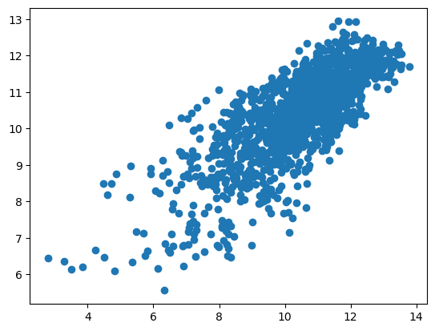

```python
# 绘制 y真值 与 y预测值 的散点图
plt.scatter(y,predictions)
```

```
                            OLS Regression Results
==============================================================================
Dep. Variable:                 Ton_ha   R-squared:                       0.602
Model:                            OLS   Adj. R-squared:                  0.598
Method:                 Least Squares   F-statistic:                     157.5
Date:                Sun, 21 May 2023   Prob (F-statistic):          3.10e-299
Time:                        15:56:59   Log-Likelihood:                -2219.6
No. Observations:                1580   AIC:                             4471.
Df Residuals:                    1564   BIC:                             4557.
Df Model:                          15
Covariance Type:            nonrobust
==============================================================================
                 coef    std err          t      P>|t|      [0.025      0.975]
------------------------------------------------------------------------------
Intercept      9.7713      0.534     18.296      0.000       8.724      10.819
GDD5           0.0015      0.001      1.254      0.210      -0.001       0.004
GDD6          -0.0110      0.002     -5.926      0.000      -0.015      -0.007
GDD7           0.0065      0.002      4.284      0.000       0.003       0.009
GDD8           0.0064      0.002      3.871      0.000       0.003       0.010
GDD9           0.0100      0.001      7.257      0.000       0.007       0.013
KDD5           0.0478      0.007      6.588      0.000       0.034       0.062
KDD6           0.0145      0.003      4.782      0.000       0.009       0.020
KDD7          -0.0254      0.002    -11.442      0.000      -0.030      -0.021
KDD8          -0.0424      0.003    -16.859      0.000      -0.047      -0.037
KDD9           0.0119      0.004      2.717      0.007       0.003       0.021
pcpn5         -0.0075      0.001    -13.058      0.000      -0.009      -0.006
pcpn6         -0.0035      0.000     -7.292      0.000      -0.004      -0.003
pcpn7         -0.0016      0.001     -2.540      0.011      -0.003      -0.000
pcpn8         -0.0016      0.001     -3.058      0.002      -0.003      -0.001
pcpn9          0.0013      0.001      2.286      0.022       0.000       0.002
==============================================================================
Omnibus:                      105.409   Durbin-Watson:                   1.487
Prob(Omnibus):                  0.000   Jarque-Bera (JB):              140.965
Skew:                          -0.583   Prob(JB):                     2.45e-31
Kurtosis:                       3.884   Cond. No.                     1.59e+04
==============================================================================

Notes:
[1] Standard Errors assume that the covariance matrix of the errors is correctly specified.
[2] The condition number is large, 1.59e+04. This might indicate that there are
strong multicollinearity or other numerical problems.
```

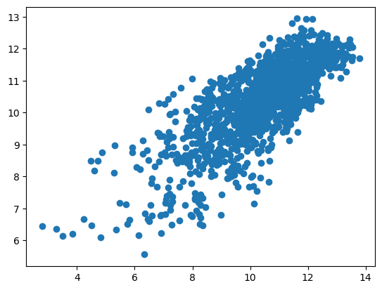

```python
# 构建最小二乘法线性模型
formula = 'Ton_ha~GDD5+GDD6+GDD7+GDD8+GDD9+KDD5+KDD6+KDD7+KDD8+KDD9+pcpn5+pcpn6+pcpn7+pcpn8+pcpn9'
model2 = smf.ols(formula=formula, data=df)
results2 = model2.fit()
print(results2.summary())
# 绘制 y真值 与 y预测值 的散点图
predictions2 = results2.predict(x)
plt.scatter(y,predictions2)
```

## 方式二 使用sklearn

```
截距： 10.322200947693442
线性模型回归系数： 10.322200947693442
R方R2_train： 0.6011336648879995
R方R2_test： 0.5934709862676384
```

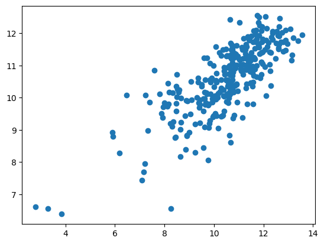

```python
import pandas as pd
import matplotlib.pyplot as plt
import numpy as np
import seaborn as sns
from sklearn.model_selection import train_test_split
from sklearn.linear_model import LinearRegression

# 读取数据
df = pd.read_csv('MergeDataSet_郑元浩_22213014.csv')
x = df[['GDD5', 'GDD6', 'GDD7', 'GDD8', 'GDD9', 'KDD5', 'KDD6', 'KDD7', 'KDD8', 'KDD9', 'pcpn5', 'pcpn6', 'pcpn7', 'pcpn8', 'pcpn9']]
y = df['Ton_ha']

# 划分训练集和预测集
x_train, x_test, y_train, y_test = train_test_split(x, y, test_size=0.2, random_state=42)

# 定义模型
model = LinearRegression()

# 拟合模型
model.fit(x_train, y_train)

# 截距  回归系数  计算R方
print("截距：",model.intercept_)
print("线性模型回归系数：",model.intercept_)
print("R方R2_train：",model.score(x_train,y_train))
print("R方R2_test：",model.score(x_test,y_test))

y_pred = model.predict(x_test)
plt.scatter(y_test,y_pred)
```